# Portfolio 1

Cynthia Jiao

02/05/2025

I picked the student survey dataset from the dsbox for my portfolio 1. Hopefully I can finish collecting my thesis data soon and I can use that data for my following portfolio pieces…

1. Take a closer look at the student survey data

From the tibble, tere are 80 students in the dataset and 53 survey questions being asked.

```r
library(tidyverse)
library(tidyr)
library(dsbox)

print(student_survey)
```

```
## # A tibble: 80 × 53
##     pets us_region        class_year hair_color campus watch_sports beyonce_love
##    <int> <chr>            <chr>      <chr>      <chr>  <chr>        <chr>
##  1     1 Southeast        Junior     Brown      West   Basketball   yes
##  2     0 Southeast        First-year Brown      East   Football     hell yes
##  3     0 Not from the US  Sophomore  Black      West   Soccer       no
##  4     1 Pacific Northwe… Junior     Brown      Off c… Football     hell yes
##  5     7 Southwest        Sophomore  Brown      West   I don't wat… hell yes
##  6     1 Mid-Atlantic     Sophomore  Brown      West   Basketball   hell yes
##  7     3 Midwest          First-year Blonde     East   I don't wat… meh
##  8     0 Mid-Atlantic     Sophomore  Brown      West   Basketball   yes
##  9     1 Mid-Atlantic     Sophomore  Blonde     Centr… Basketball   hell yes
## 10     1 Midwest          First-year Brown      East   Basketball   yes
## # ℹ 70 more rows
## # ℹ 46 more variables: fav_artist <chr>, social_network <chr>,
## #   relationship_status <chr>, num_siblings <int>, num_languages <chr>,
## #   nights_drinking <dbl>, pbj_or_n <chr>, tenting <chr>,
## #   countries_visited <int>, first_kiss <int>, hours_watching_television <dbl>,
## #   perimeter <chr>, fav_campus_eatery <chr>, fb_visits_per_day <int>,
## #   ac <chr>, condiment <chr>, vegetarian <chr>, voted_for_president <chr>, …
```

2. Plot the relationship between chocolate lover and preference for peanut butter, jelly, or nutella.

Chocolate is the most loved flavor (41 votes). Therefore, I wonder if those who love chocolate will also choose nutella over pb & jelly (pbj_or_n). Therefore, I created a new binary variable for chocolate lovers called “chocolate,” and I want to see its relationship with pbj_or_n variable through a barplot. From the plot, although there are both chocolate or non-chocolate lovers showing preference for the some combinations of pb, jelly, and nutella, there are more chocolate lovers who choose nutella over pb & j than non-chocolate lovers.

```r
## counting the most loved dessert flavor and preference among peanut butter, jelly and nutella.

student_survey %>%
  count(fav_dessert_flavor)
```

```
## # A tibble: 6 × 2
##   fav_dessert_flavor     n
##   <chr>              <int>
## 1 chocolate             41
## 2 fruity                 9
## 3 other                  3
## 4 sour                   1
## 5 sweet-and-salty       12
## 6 vanilla               14
```

```r
student_survey %>%
  count(pbj_or_n)
```

```
## # A tibble: 6 × 2
##   pbj_or_n                    n
##   <chr>                   <int>
## 1 All three                   5
## 2 Jelly                       2
## 3 None                        2
## 4 Nutella                    28
## 5 Peanut butter              15
## 6 Some combination of two    28
```

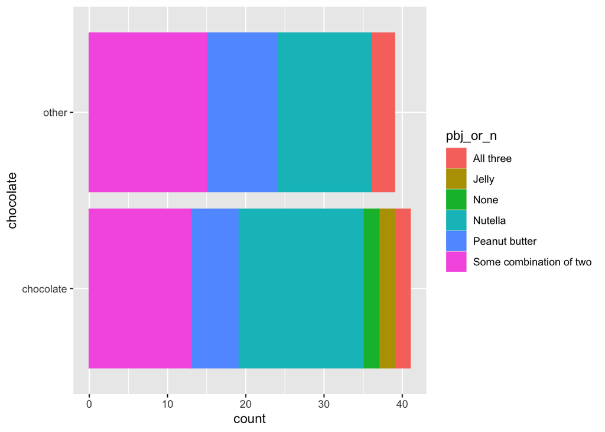

```r
## creating the new variable for people who choose chocolate as their favorite flavor and others
p01.2 <- student_survey %>%
   mutate(
    chocolate = if_else(fav_dessert_flavor == "chocolate", "chocolate", "other")
  )

## plot for the relationship between chocolate lover and preference for peanut butter, chocolate, or jelly.
ggplot(p01.2, mapping = aes(
  y = chocolate,
  color = pbj_or_n,
  fill = pbj_or_n
)) +
  geom_bar()
```

3. Plot the relationship between multicultural identities and us regions

Next, I want to know which us regions have more people who identify as multicultural. Since the current dataset include both international and domestic students, I want to first filter out those who are international students.

From the barplot, most students who identify as multicultural are from Southeast, followed by New England and Mid-Altantic. But this is probably because that there are more students from Southeast take the survey, instead of suggesting that there is a positive relationship between multicultural id and Southeast regions. If there is a large dataset, calculating the ratio of multicultural individuls vs. non multicultural individuals for each region could help better interpret the results (just by looking at the graph of this dataset, California has the highest ratio of 1).

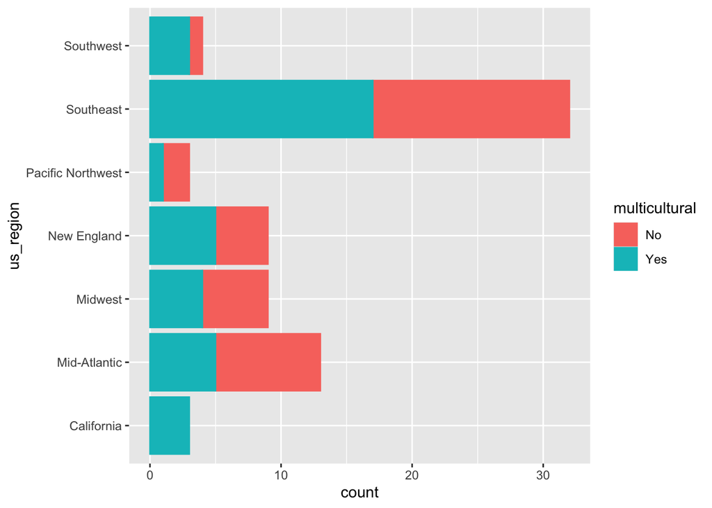

```r
## filter out those who are not from US from us_region

p01.3 <- student_survey %>%
  filter(!us_region == "Not from the US")

## plot the relationship between multicultural identities and us regions

ggplot(p01.3, mapping = aes(
  y = us_region,
  color = multicultural,
  fill = multicultural
)) +
  geom_bar()
```

4. Plot the relationship between numbers of countries visited and numbers of continents visited for domestic and international students

Lastly, I want to know whether there seems to be a positive relationship between the number of countries visited and continents visited, and I want to know if this relationship looks different for domestic and international students.

From the scatterplot, there seems to be a strong positive relationship between countries and continents visited for all students, such that if they visit more countries, they will visit more continents. This relationship is especially clear for domestic students, shown as red dots in the plot. There seems to be somewhat similar patterns for international students, but due to the limited numbers of international students (blue dots), I cannot be sure.

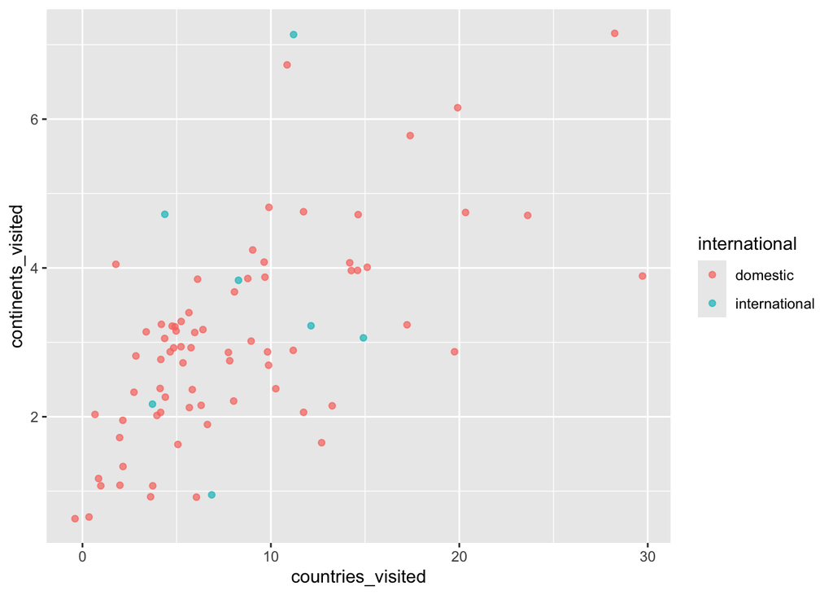

```r
## creating the new variable for people who are domestic or international students
p01.4 <- student_survey %>%
  mutate(
    international = if_else(us_region == "Not from the US", "international", "domestic")
  )

## plot the relationship using scatterplot

ggplot(p01.4, mapping = aes(
  x = countries_visited,
  y = continents_visited,
  color = international,
  fill = international
)) +
  geom_jitter(alpha=0.7)
```